# R Notebook

# Housekeeping

## Load packages

```r
library(tidyverse)
library(lme4)
library(MASS)
library(MuMIn)
library(emmeans)
library(boot)
library(brms)
library(loo)
library(fitdistrplus)
library(mefa)
library(ggbiplot)
library(pvclust)
library(vegan)
library(ggbiplot)
library(factoextra)
library(glmmADMB)
library(car)
library(effects)
library(coefplot2)
library(bbmle)
library(gridExtra)
library(corrplot)
library(ade4)
```

## Load costum functions

```r
residfit <- function (model, col="black") {
  f<-fitted(model)
  r<-resid(model, type='pearson')
  plot(f, r, col=col, main='Residuals vs. Fitted')
  L1<-loess(r~f)
  fvec = seq(min(f),max(f),length.out=1000)
  lines(fvec,predict(L1,fvec),col='red')
}

#do the same for the Scale-Location plot
scaleloc <- function(model,col="black") {
  f <- fitted(model)
  r <- sqrt(abs(residuals(model, type='pearson'))) #transformed pearson residuals
  plot(f,r,col=col, main='Scale-Location Plot')
  L1 <- loess(r~f)
  fvec = seq(min(f),max(f),length.out=1000)
  lines(fvec,predict(L1,fvec),col=2)
}
```

## Load data

### Load/ Modify data: Co-occurence

```
## [1] 99.55752
```

```
## [1] 100
```

| indiv2 | Decay | Pathogen | Hyphae | None.Path | Arbuscules | Vesicles | M_Hyphae | None.Myc | Herbivory | None.Herb | Lesion |
| --- | --- | --- | --- | --- | --- | --- | --- | --- | --- | --- | --- |

| indiv2 | Decay | Pathogen | Hyphae | None.Path | Arbuscules | Vesicles | M_Hyphae | None.Myc | Herbivory | None.Herb | Lesion | Mycorrhiza |
| --- | --- | --- | --- | --- | --- | --- | --- | --- | --- | --- | --- | --- |

```
##      indiv2       None.Path           None.Myc           Herbivory
##  10IAH1 :  100   Length:22500       Length:22500       Min.   :0.00000
##  10IAH2 :  100   Class :character   Class :character   1st Qu.:0.00000
##  10ISC1 :  100   Mode  :character   Mode  :character   Median :0.00000
##  10ISC2 :  100                                         Mean   :0.03658
##  10ISC3 :  100                                         3rd Qu.:0.00000
##  10OAH1 :  100                                         Max.   :1.00000
##  (Other):21900
##    None.Herb          Lesion        Mycorrhiza
##  Min.   :0.0000   Min.   :0.000   Min.   :0.0000
##  1st Qu.:1.0000   1st Qu.:0.000   1st Qu.:0.0000
##  Median :1.0000   Median :1.000   Median :1.0000
##  Mean   :0.9631   Mean   :0.622   Mean   :0.5732
##  3rd Qu.:1.0000   3rd Qu.:1.000   3rd Qu.:1.0000
##  Max.   :1.0000   Max.   :1.000   Max.   :1.0000
##
```

|  | indiv2 | None.Path | None.Myc | Herbivory | None.Herb | Lesion | Mycorrhiza |
| --- | --- | --- | --- | --- | --- | --- | --- |
| 1573 | 7ISC1 | 0 | 0 | 0 | 0 | 1 | 1 |
| 1587 | 7ISC1 | 0 | 0 | 0 | 0 | 1 | 1 |
| 1729 | 7ISC2 | 1 | 0 | 0 | 0 | 0 | 1 |
| 9107 | 5OSC2 | 1 | 1 | 0 | 0 | 0 | 0 |
| 9154 | 3ISC3 | 1 | 1 | 0 | 0 | 0 | 0 |
| 14441 | 5OAH1 | 0 | 0 | 0 | 0 | 1 | 1 |
| 23150 | 7OCL1 | 0 | 1 | 0 | 0 | 1 | 0 |
| 23253 | 3OMR2 | 1 | 1 | 0 | 0 | 0 | 0 |

| counter | Indiv2 | Sum |
| --- | --- | --- |

| counter | Indiv2 | Sum |
| --- | --- | --- |

| counter | Indiv2 | Sum |
| --- | --- | --- |

```
##     indiv2            None.Path        None.Myc        Herbivory
##  Length:22500       Min.   :0.000   Min.   :0.0000   Min.   :0.00000
##  Class :character   1st Qu.:0.000   1st Qu.:0.0000   1st Qu.:0.00000
##  Mode  :character   Median :0.000   Median :0.0000   Median :0.00000
##                     Mean   :0.378   Mean   :0.4268   Mean   :0.03658
##                     3rd Qu.:1.000   3rd Qu.:1.0000   3rd Qu.:0.00000
##                     Max.   :1.000   Max.   :1.0000   Max.   :1.00000
##
##    None.Herb          Lesion        Mycorrhiza          pop
##  Min.   :0.0000   Min.   :0.000   Min.   :0.0000   5      :2900
##  1st Qu.:1.0000   1st Qu.:0.000   1st Qu.:0.0000   7      :2600
##  Median :1.0000   Median :1.000   Median :1.0000   8      :2600
##  Mean   :0.9634   Mean   :0.622   Mean   :0.5732   3      :2200
##  3rd Qu.:1.0000   3rd Qu.:1.000   3rd Qu.:1.0000   4      :2200
##  Max.   :1.0000   Max.   :1.000   Max.   :1.0000   1      :2000
##                                                    (Other):8000
##  location  species
##  I:10600   AH:3100
##  O:11900   CL:3900
##            GA:4900
##            GR:1300
##            MR:3100
##            SC:6200
##
```

```
##     indiv2          None.Path None.Myc  Herbivory None.Herb Lesion
##  Length:22500       0:13995   0:12897   0:21677   0:  823   0: 8505
##  Class :character   1: 8505   1: 9603   1:  823   1:21677   1:13995
##  Mode  :character
##
##
##
##
##  Mycorrhiza      pop       location  species
##  0: 9603    5      :2900   I:10600   AH:3100
##  1:12897    7      :2600   O:11900   CL:3900
##             8      :2600             GA:4900
##             3      :2200             GR:1300
##             4      :2200             MR:3100
##             1      :2000             SC:6200
##             (Other):8000
```

### Load/ Modify data: Totals

```
## [1] 226
```

```
## [1] 226
```

```
##      indiv         Decay           Pathogen          Hyphae
##  10IAH1 :  1   Min.   : 0.000   Min.   : 0.000   Min.   : 2.00
##  10IAH2 :  1   1st Qu.: 1.000   1st Qu.: 2.000   1st Qu.:34.00
##  10ISC1 :  1   Median : 4.000   Median : 4.000   Median :48.00
##  10ISC2 :  1   Mean   : 7.894   Mean   : 7.168   Mean   :47.23
##  10ISC3 :  1   3rd Qu.: 9.000   3rd Qu.:10.000   3rd Qu.:63.00
##  10OAH1 :  1   Max.   :60.000   Max.   :86.000   Max.   :96.00
##  (Other):220
##    None.Path       Arbuscules        Vesicles         M_Hyphae
##  Min.   : 0.00   Min.   : 0.000   Min.   : 0.000   Min.   : 0.00
##  1st Qu.:20.00   1st Qu.: 0.000   1st Qu.: 1.000   1st Qu.:30.25
##  Median :33.00   Median : 0.000   Median : 6.000   Median :46.00
##  Mean   :37.71   Mean   : 2.363   Mean   : 9.956   Mean   :45.16
##  3rd Qu.:53.75   3rd Qu.: 3.000   3rd Qu.:14.000   3rd Qu.:61.00
##  Max.   :97.00   Max.   :21.000   Max.   :73.000   Max.   :94.00
##
##     None.Myc        Herbivory        None.Herb         Lesions
##  Min.   :  0.00   Min.   : 0.000   Min.   : 62.00   Min.   :  3.00
##  1st Qu.: 18.00   1st Qu.: 0.000   1st Qu.: 96.00   1st Qu.: 46.25
##  Median : 38.50   Median : 1.000   Median : 99.00   Median : 67.00
##  Mean   : 42.52   Mean   : 3.624   Mean   : 96.38   Mean   : 62.29
##  3rd Qu.: 66.00   3rd Qu.: 4.000   3rd Qu.:100.00   3rd Qu.: 80.00
##  Max.   :100.00   Max.   :38.000   Max.   :100.00   Max.   :100.00
##
##    Mycorrhiza          pop     location species
##  Min.   :  0.00   5      :29   I:106    AH:31
##  1st Qu.: 34.00   8      :27   O:120    CL:39
##  Median : 61.50   7      :26            GA:50
##  Mean   : 57.48   3      :22            GR:13
##  3rd Qu.: 82.00   4      :22            MR:31
##  Max.   :100.00   1      :20            SC:62
##                   (Other):80
```

### Field survey data

```r
FloristicSurvey <-read.csv("CSV/May_2017_FloristicSurvey_summer2016.csv", sep="\t")
PlantLength <- read.csv("CSV/May_2017_PlantLength_summer2016.csv", sep="\t")
Soil_characteristics <- read.csv("CSV/Soil_characteristics.txt", sep="\t")

#Restructuring
head(PlantLength)
```

|  | Pop | Location | Species | Length_plant |
| --- | --- | --- | --- | --- |
| 1 | 14 | out | Acer_saccharum | 14 |
| 2 | 14 | out | Gallium_aparine | 87 |
| 3 | 14 | out | Circaea_lutetiana | 20 |
| 4 | 14 | out | Geranium_robertinum | 12 |
| 5 | 14 | out | Solidago_canadensis | 67 |
| 6 | 14 | in | Acer_saccharum | 11 |

```r
str(PlantLength)
```

```
## 'data.frame':    231 obs. of  4 variables:
##  $ Pop         : int  14 14 14 14 14 14 14 14 14 14 ...
##  $ Location    : Factor w/ 2 levels "in","out": 2 2 2 2 2 1 1 1 1 1 ...
##  $ Species     : Factor w/ 7 levels "Acer_saccharum",..: 1 4 3 5 7 1 4 3 5 7 ...
##  $ Length_plant: num  14 87 20 12 67 11 65 51 20 100 ...
```

```r
colnames(PlantLength)[1] <- "Population"
PlantLength$Population<-as.factor(PlantLength$Population)
PlantLength$Location<-as.factor(PlantLength$Location)

FloristicSurvey$Population<-as.factor(FloristicSurvey$Population) # Make the population a factor and not an interger
FloristicSurvey[is.na(FloristicSurvey)] <- 0
sum(row.has.na <- apply(FloristicSurvey, 1, function(x){any(is.na(x))}))
```

```
## [1] 0
```

### Root size

```r
Root_size <-read.csv("CSV/Root_size.csv")
Root_size$pop<-gsub("^([0-9]+)[I,O][A-Z]+.*","\\1",Root_size$indiv)
Root_size$location<-gsub("^[0-9]+([I,O])[A-Z]+.*","\\1",Root_size$indiv)
Root_size$species<-gsub("^[0-9]+[I,O]([A-Z]+).*","\\1",Root_size$indiv)
Root_size$location<-as.factor(Root_size$location)
Root_size$species<-as.factor(Root_size$species)
Root_size$pop<-as.factor(Root_size$pop)
```

### Make a full dataset

```r
Soil_characteristics$Location<-as.character(Soil_characteristics$Location)
for(i in 1:length(Soil_characteristics$Location))if(Soil_characteristics[i,2]=="in"){
   Soil_characteristics[i,2]<-"I"
}else{
  Soil_characteristics[i,2]<-"O"
}
Soil_characteristics$Location<-as.factor(Soil_characteristics$Location)
names(Soil_characteristics)[1:2]<-c("pop","location")

fulldata <- merge(Soil_characteristics, ndata, by=c("pop","location"))
names(Root_size)[1]<-"indiv"
fulldata <- merge(fulldata, Root_size, by=c("indiv","location","pop","species"))
for(i in 1:length(fulldata$indiv)){
fulldata$mean_rootsize[i]<-(sum(fulldata[i,20:29])/length(fulldata[,20:29]))
}
fulldata<-fulldata[,-c(20:29)]

binlesionF<-cbind(fulldata$None.Path,100-fulldata$None.Path)
binmycorrF<-cbind(fulldata$None.Myc,100-fulldata$None.Myc)
binherbivoryF<-cbind(fulldata$None.Herb,100-fulldata$None.Herb)


fulldata$pop<-as.factor(fulldata$pop)
fulldata$Mycorrhiza<-100-fulldata$None.Myc
fulldata$Lesion<-100-fulldata$None.Path
```

# Variable descriptions

### Co-occurence

- **indiv2:** The unique code given to a sample. In this dataset the unique sample code repeats 100 times for each cross where an observation was taken on the root sample.
- **None.Path:** A binary representation of whether a sign of pathogen activity was recorded (0) or not (1).
- **Lesion:** The counterpart to the previous variable (None.Path). A binary representation of whether a sign of pathogen activity was recorded (1) or not (0).
- **None.Myc:** A binary representation of whether a sign of myccorhizal activity was recorded (0) or not (1).
- **Mycorrhiza:** The counterpart to the previous variable (None.Myc). A binary representation of whether a sign of mycorrhizal activity was recorded (1) or not (0).
- **None.Herb:** A binary representation of whether herbivory was recorded (0) or not (1).
- **Herbivory:** The counterpart to the previous variable (None.Herb). A binary representation of whether Herbivoryn was recorded (1) or not (0).
- **Population (pop):** The coding number representing the population at which the sample was collected.
- **location:** A code representing the whether the sample was collected inside a Alliaria petiolata population (I) or whther it was collected at least 7 m outside of he furthest individual in the A. petiolata population (O).
- **species:** The particular species to which the sample belongs.
- **Cross:** The particular cross number where the data was recorded on the individual sample.

### Total scores

- **indiv:** The unique code given to a sample.
- **Decay:** The total number of crosses where decay was recorded an individual sample when doing a total of 100 crosses/ sample.
- **Pathogen:** The total number of crosses where pathogen was recorded on an individual sample when doing a total of 100 crosses/ sample.
- **Hyphae:** The total number of crosses where non-myccorhizal hyphae was recorded on an individual sample when doing a total of 100 crosses/ sample.
- **None.Path:** The total number of crosses where no signs of pathogen activities were recorded on an individual sample when doing a total of 100 crosses/ sample. Note that the total of Decay, Pathogen, Hyphae, and None.Path must come to 100 per individual to account for all 100 crosses.
- **Arbuscule:** The total number of crosses where an arbuscule was recorded on an individual sample when doing a total of 100 crosses/ sample.
- **Vesicules:** The total number of crosses where a vesicule was recorded on an individual sample when doing a total of 100 crosses/ sample.
- **M_Hyphae:** The total number of crosses where myccorhizal hyphae was recorded on an individual sample when doing a total of 100 crosses/ sample.
- **None.Myc:** The total number of crosses where no signs of mycorrhizal activities were recorded on an individual sample when doing a total of 100 crosses/ sample. Note that the total of Arbuscules, Vesicules, M_Hyphae, and None.Myc must come to 100 per individual to account for all 100 crosses.
- **Herbivory:** The total number of crosses where herbivory was recorded on an individual sample when doing a total of 100 crosses/ sample.
- **None.Herb:** The total number of crosses where no signs of herbivory was recorded on an individual sample when doing a total of 100 crosses/ sample. Note that the total of Herbivory, and None.Herb must come to 100 per individual to account for all 100 crosses.
- **Population (pop):** The coding number representing the population at which the sample was collected.
- **location:** A code representing the whether the sample was collected inside a Alliaria petiolata population (I) or whther it was collected at least 7 m outside of he furthest individual in the A. petiolata population (O).
- **species:** The particular species to which the sample belongs.

# Soil abiotic qualities and location

### Model selection

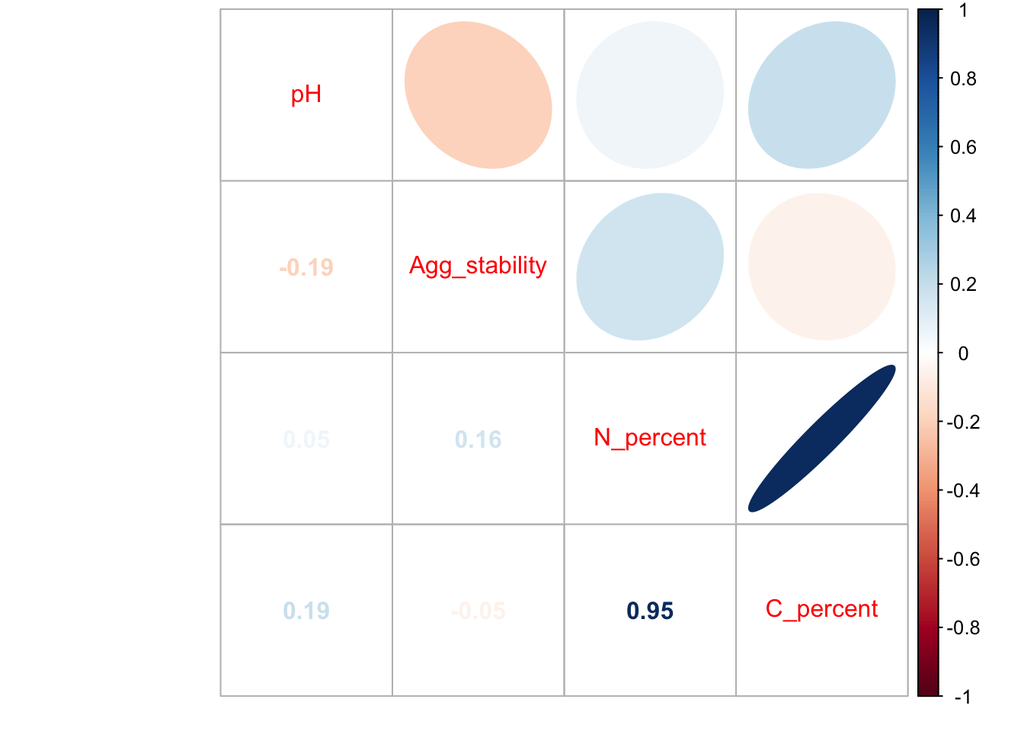

```r
var<-Soil_characteristics[,c(1,2)]
Y<-Soil_characteristics[,-c(1,2,5)]
var$pop<-as.factor(var$pop)
Location<-as.factor(var$location)
Y$Sample <-paste(var$pop,var$location)
rownames(Y)<-Y$Sample
Y$Sample<-NULL

covar_cor = cor(Y)
corrplot.mixed(covar_cor, upper = "ellipse", lower = "number")
```

```r
Nutrient_PCA = dudi.pca(df = Y[, c(3, 4)], scannf = FALSE, nf = 1)
Nutrient_PCA$co
```

|  | Comp1 |
| --- | --- |
| N_percent | 0.9884904 |
| C_percent | 0.9884904 |

```r
Nutrient_PCA$eig/sum(Nutrient_PCA$eig)
```

```
## [1] 0.97711334 0.02288666
```

```r
Soil_characteristics$Nutrient_PC1 = Nutrient_PCA$li[,1]

dat<-data.frame(c(1:20))
dat[1]<-Soil_characteristics$location
colnames(dat)[1]<-"Location"
dat$Agg_stability.s<-scale(Soil_characteristics$Agg_stability)
dat$pH.s<-scale(Soil_characteristics$pH)
dat$Nutrient_PC1.s<-scale(Soil_characteristics$Nutrient_PC1)

GLM_soil <- glm(Location~Agg_stability.s*pH.s*Nutrient_PC1.s,
                    family=binomial(link='logit'),
                    data=dat)
```

### LRT

```r
GLM_soil2 <- glm(Location~Agg_stability.s+pH.s+Nutrient_PC1.s+
                   Agg_stability.s:pH.s + Agg_stability.s:Nutrient_PC1.s+
                   Nutrient_PC1.s:pH.s,
                family=binomial(link='logit'),
                data=dat)
anova(GLM_soil,GLM_soil2)
```

|  | Resid. Df | Resid. Dev | Df | Deviance |
| --- | --- | --- | --- | --- |
| 1 | 12 | 18.61078 | NA | NA |
| 2 | 13 | 18.86103 | -1 | -0.2502518 |

```r
GLM_soil3 <- glm(Location~Agg_stability.s+pH.s+Nutrient_PC1.s+
                   Agg_stability.s:pH.s + Agg_stability.s:Nutrient_PC1.s,
                 family=binomial(link='logit'),
                 data=dat)
anova(GLM_soil2,GLM_soil3)
```

|  | Resid. Df | Resid. Dev | Df | Deviance |
| --- | --- | --- | --- | --- |
| 1 | 13 | 18.86103 | NA | NA |
| 2 | 14 | 18.90156 | -1 | -0.04053231 |

```r
GLM_soil4 <- glm(Location~Agg_stability.s+pH.s+Nutrient_PC1.s+
                   Agg_stability.s:pH.s,
                 family=binomial(link='logit'),
                 data=dat)
anova(GLM_soil3,GLM_soil4)
```

|  | Resid. Df | Resid. Dev | Df | Deviance |
| --- | --- | --- | --- | --- |
| 1 | 14 | 18.90156 | NA | NA |
| 2 | 15 | 20.77074 | -1 | -1.869175 |

```r
GLM_soil5 <- glm(Location~Agg_stability.s+pH.s+Nutrient_PC1.s,
                 family=binomial(link='logit'),
                 data=dat)
anova(GLM_soil4,GLM_soil5)
```

|  | Resid. Df | Resid. Dev | Df | Deviance |
| --- | --- | --- | --- | --- |
| 1 | 15 | 20.77074 | NA | NA |
| 2 | 16 | 22.48553 | -1 | -1.714793 |

```r
GLM_soil6 <- glm(Location~Agg_stability.s+pH.s,
                 family=binomial(link='logit'),
                 data=dat)
anova(GLM_soil5,GLM_soil6)
```

|  | Resid. Df | Resid. Dev | Df | Deviance |
| --- | --- | --- | --- | --- |
| 1 | 16 | 22.48553 | NA | NA |
| 2 | 17 | 22.50282 | -1 | -0.01728831 |

```r
GLM_soil7 <- glm(Location~Agg_stability.s,
                 family=binomial(link='logit'),
                 data=dat)
anova(GLM_soil6,GLM_soil7)
```

|  | Resid. Df | Resid. Dev | Df | Deviance |
| --- | --- | --- | --- | --- |
| 1 | 17 | 22.50282 | NA | NA |
| 2 | 18 | 26.55163 | -1 | -4.048813 |

```r
GLM_soil8 <- glm(Location~1,
                 family=binomial(link='logit'),
                 data=dat)
anova(GLM_soil7,GLM_soil8)
```

|  | Resid. Df | Resid. Dev | Df | Deviance |
| --- | --- | --- | --- | --- |
| 1 | 18 | 26.55163 | NA | NA |
| 2 | 19 | 27.72589 | -1 | -1.174256 |

### descriptive stats

```r
summary(GLM_soil)
```

```
##
## Call:
## glm(formula = Location ~ Agg_stability.s * pH.s * Nutrient_PC1.s,
##     family = binomial(link = "logit"), data = dat)
##
## Deviance Residuals:
##      Min        1Q    Median        3Q       Max
## -1.61136  -0.76251   0.03445   0.69292   2.24270
##
## Coefficients:
##                                     Estimate Std. Error z value Pr(>|z|)
## (Intercept)                          -0.9003     0.9455  -0.952    0.341
## Agg_stability.s                       0.1026     1.1377   0.090    0.928
## pH.s                                 -1.4113     0.9445  -1.494    0.135
## Nutrient_PC1.s                       -0.9706     1.1953  -0.812    0.417
## Agg_stability.s:pH.s                 -1.7730     1.2825  -1.382    0.167
## Agg_stability.s:Nutrient_PC1.s        1.4842     1.3079   1.135    0.256
## pH.s:Nutrient_PC1.s                  -0.4288     1.7075  -0.251    0.802
## Agg_stability.s:pH.s:Nutrient_PC1.s  -1.1731     2.3671  -0.496    0.620
##
## (Dispersion parameter for binomial family taken to be 1)
##
##     Null deviance: 27.726  on 19  degrees of freedom
## Residual deviance: 18.611  on 12  degrees of freedom
## AIC: 34.611
##
## Number of Fisher Scoring iterations: 5
```

```r
confint(GLM_soil)
```

```
##                                          2.5 %    97.5 %
## (Intercept)                         -3.2687501 0.7760833
## Agg_stability.s                     -2.2683850 2.5498269
## pH.s                                -3.9025305 0.2426490
## Nutrient_PC1.s                      -3.8109903 1.3550658
## Agg_stability.s:pH.s                -5.6201054 0.1096696
## Agg_stability.s:Nutrient_PC1.s      -0.9164553 4.8513043
## pH.s:Nutrient_PC1.s                 -4.3894775 3.1671037
## Agg_stability.s:pH.s:Nutrient_PC1.s -6.8716680 3.5148397
```

```r
pr<-resid(GLM_soil, type='pearson')
n<-nrow(Soil_characteristics)
c<-length(coef(GLM_soil))
(Disp<-sum(pr^2)/(n-c))
```

```
## [1] 1.770866
```

# Garlic mustard on Mycorrhiza

### Model selection

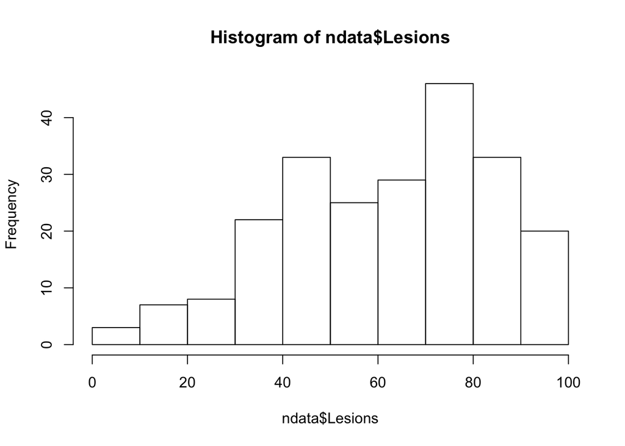

```r
hist(ndata$Lesions)
```

```r
mod1.binom<-glmmadmb(binmycorr ~ species + location + species:location +
                       (1|pop),
                     data=ndata, family="binomial")

mod1.binom.ind<-glmmadmb(binmycorr ~ species + location + species:location +
                 (1|pop)+ (1|indiv),
               data=ndata, family="binomial")

mod1.poisson.ind <-glmmadmb(Mycorrhiza ~ species + location + species:location +
                    (1|pop)+ (1|indiv),
                  data=ndata, family="poisson")

mod1.poisson <-glmmadmb(Mycorrhiza ~ species + location + species:location +
                         (1|pop),
                       data=ndata, family="poisson")

mod1.nb<-glmmadmb(Mycorrhiza ~ species + location + species:location +
                    (1|pop),
                  data=ndata, family="nbinom1")


mod1.nb.ind<-glmmadmb(Mycorrhiza ~ species + location + species:location +
                 (1|pop)+ (1|indiv),
               data=ndata, family="nbinom1")

ICtab(mod1.binom, mod1.binom.ind ,mod1.poisson, mod1.poisson.ind ,mod1.nb, mod1.nb.ind)
```

```
##                  dAIC   df
## mod1.binom.ind      0.0 14
## mod1.nb.ind       105.2 15
## mod1.nb           106.1 14
## mod1.poisson.ind  185.1 14
## mod1.poisson     1904.5 13
## mod1.binom       5817.1 13
```

### LRT

```r
mod1.1<-glmmadmb(binmycorr ~ species + location +
                   (1|pop) + (1|indiv),
               data=ndata, family="binomial")
anova(mod1.1, mod1.binom.ind)
```

|  | NoPar | LogLik | Df | Deviance | Pr(>Chi) |
| --- | --- | --- | --- | --- | --- |
| 1 | 9 | -1024.27 | NA | NA | NA |
| 2 | 14 | -1022.66 | 5 | 3.22 | 0.6661101 |

```r
mod1.2<-glmmadmb(binmycorr ~ species + species:location +
                   (1|pop)+ (1|indiv),
               data=ndata, family="binomial")
anova(mod1.2, mod1.binom.ind)
```

|  | NoPar | LogLik | Df | Deviance | Pr(>Chi) |
| --- | --- | --- | --- | --- | --- |
| 1 | 14 | -1022.66 | NA | NA | NA |
| 2 | 14 | -1022.66 | 0 | 0 | 1 |

```r
mod1.3<-glmmadmb(binmycorr ~ species +
                   (1|pop)+ (1|indiv),
               data=ndata, family="binomial")
anova(mod1.3 ,mod1.2)
```

|  | NoPar | LogLik | Df | Deviance | Pr(>Chi) |
| --- | --- | --- | --- | --- | --- |
| 1 | 8 | -1024.32 | NA | NA | NA |
| 2 | 14 | -1022.66 | 6 | 3.32 | 0.7677432 |

```r
mod1.4<-glmmadmb(binmycorr ~ 1 +
                   (1|pop) + (1|indiv),
                 data=ndata, family="binomial")
anova(mod1.4 , mod1.3)
```

|  | NoPar | LogLik | Df | Deviance | Pr(>Chi) |
| --- | --- | --- | --- | --- | --- |
| 1 | 3 | -1034.12 | NA | NA | NA |
| 2 | 8 | -1024.32 | 5 | 19.6 | 0.001485149 |

### Descriptive stats

```r
pr<-resid(mod1.3, type='pearson')
n<-nrow(ndata)
c<-length(coef(mod1.3))
(Disp<-sum(pr^2)/(n-c))
```

```
## [1] 0.07671148
```

```r
summary(mod1.3)
```

```
##
## Call:
## glmmadmb(formula = binmycorr ~ species + (1 | pop) + (1 | indiv),
##     data = ndata, family = "binomial")
##
## AIC: 2064.6
##
## Coefficients:
##             Estimate Std. Error z value Pr(>|z|)
## (Intercept)    0.117      0.265    0.44  0.65946
## speciesCL     -0.173      0.355   -0.49  0.62637
## speciesGA     -0.254      0.337   -0.75  0.45062
## speciesGR     -0.639      0.487   -1.31  0.18941
## speciesMR     -0.640      0.374   -1.71  0.08709 .
## speciesSC     -1.184      0.325   -3.65  0.00026 ***
## ---
## Signif. codes:  0 '***' 0.001 '**' 0.01 '*' 0.05 '.' 0.1 ' ' 1
##
## Number of observations: total=226, pop=11, indiv=226
## Random effect variance(s):
```

```
## Group=pop
##              Variance   StdDev
## (Intercept) 1.239e-07 0.000352
## Group=indiv
##             Variance StdDev
## (Intercept)    2.099  1.449
##
##
## Log-likelihood: -1024.32
```

```r
confint(mod1.2)
```

```
##                          2.5 %      97.5 %
## (Intercept)         -0.6444642  0.88646368
## speciesCL           -1.2121330  0.81102021
## speciesGA           -1.3383641  0.58812367
## speciesGR           -2.9516065  0.30310973
## speciesMR           -1.5871462  0.57653647
## speciesSC           -1.8782580 -0.02981598
## speciesAH:locationO -1.0416240  1.02453087
## speciesCL:locationO -0.8782452  0.96741372
## speciesGA:locationO -0.5849431  1.03371273
## speciesGR:locationO -0.7424556  2.70637542
## speciesMR:locationO -1.2872761  0.77923156
## speciesSC:locationO -1.1966969  0.26520105
```

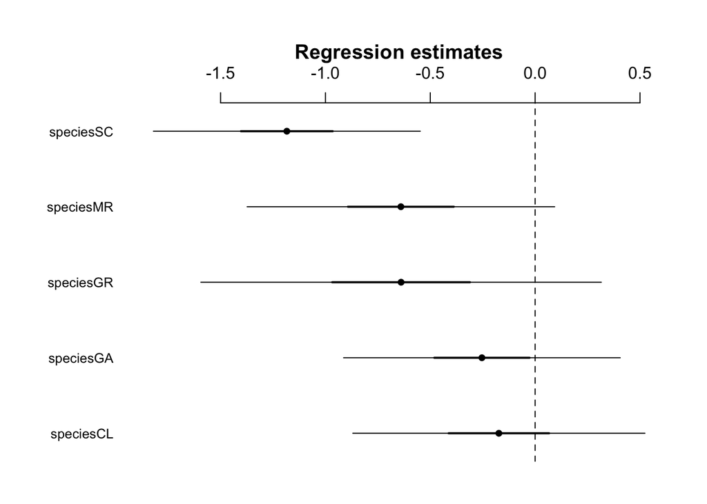

```r
# no efffect on colonization... maybe the plantswere there before GM?
coefplot2(mod1.3)
```

# Garlic mustard on Lesion

### Model selection

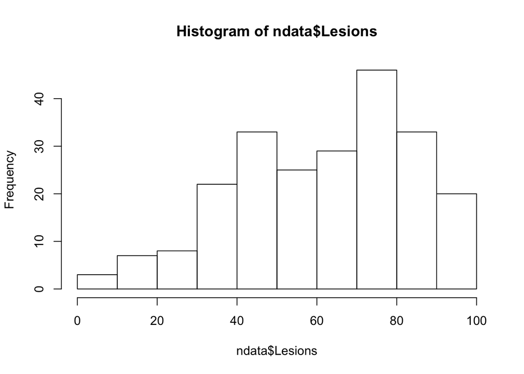

```r
hist(ndata$Lesions)
```

```r
mod2.binom<-glmmadmb(binlesion ~ species + location + species:location +
                       (1|pop),
                     data=ndata, family="binomial")

mod2.binom.ind<-glmmadmb(binlesion ~ species + location + species:location +
                       (1|pop)+ (1|indiv),
                     data=ndata, family="binomial")

mod2.poisson<-glmmadmb(Lesions ~ species + location + species:location +
                    (1|pop),
                  data=ndata, family="poisson")

mod2.poisson.ind<-glmmadmb(Lesions ~ species + location + species:location +
                         (1|pop)+ (1|indiv),
                       data=ndata, family="poisson")

mod2.nb.ind<-glmmadmb(Lesions ~ species + location + species:location +
                 (1|pop)+ (1|indiv),
               data=ndata, family="nbinom1")

mod2.nb<-glmmadmb(Lesions ~ species + location + species:location +
                    (1|pop),
                  data=ndata, family="nbinom1")

ICtab(mod2.binom,mod2.binom.ind,mod2.poisson,mod2.poisson.ind,mod2.nb,mod2.nb.ind)
```

```
##                  dAIC   df
## mod2.binom.ind      0.0 14
## mod2.nb            70.9 14
## mod2.nb.ind        71.0 15
## mod2.poisson.ind  167.4 14
## mod2.poisson      892.5 13
## mod2.binom       3295.0 13
```

### LRT

```r
mod2.1<-glmmadmb(binlesion ~ species + location +
                   (1|pop) + (1|indiv),
                 data=ndata, family="binomial")
anova(mod2.1, mod2.binom.ind)
```

|  | NoPar | LogLik | Df | Deviance | Pr(>Chi) |
| --- | --- | --- | --- | --- | --- |
| 1 | 9 | -996.417 | NA | NA | NA |
| 2 | 14 | -991.843 | 5 | 9.148 | 0.1033046 |

```r
mod2.2<-glmmadmb(binmycorr ~ species +
                   (1|pop)+ (1|indiv),
                 data=ndata, family="binomial")
anova(mod2.2,mod2.1)
```

|  | NoPar | LogLik | Df | Deviance | Pr(>Chi) |
| --- | --- | --- | --- | --- | --- |
| 1 | 8 | -1024.320 | NA | NA | NA |
| 2 | 9 | -996.417 | 1 | 55.806 | 7.993606e-14 |

```r
mod2.3<-glmmadmb(binmycorr ~ location +
                   (1|pop)+ (1|indiv),
                 data=ndata, family="binomial")
anova(mod2.3 ,mod2.1)
```

|  | NoPar | LogLik | Df | Deviance | Pr(>Chi) |
| --- | --- | --- | --- | --- | --- |
| 1 | 4 | -1034.100 | NA | NA | NA |
| 2 | 9 | -996.417 | 5 | 75.366 | 7.771561e-15 |

```r
mod2.4<-glmmadmb(binmycorr ~ 1 +
                   (1|pop) + (1|indiv),
                 data=ndata, family="binomial")
anova(mod2.4 , mod2.1)
```

|  | NoPar | LogLik | Df | Deviance | Pr(>Chi) |
| --- | --- | --- | --- | --- | --- |
| 1 | 3 | -1034.120 | NA | NA | NA |
| 2 | 9 | -996.417 | 6 | 75.406 | 3.164136e-14 |

### Descriptive stats

```r
pr<-resid(mod2.1, type='pearson')
n<-nrow(ndata)
c<-length(coef(mod2.1))
(Disp<-sum(pr^2)/(n-c))
```

```
## [1] 0.09534701
```

```r
summary(mod2.1)
```

```
##
## Call:
## glmmadmb(formula = binlesion ~ species + location + (1 | pop) +
##     (1 | indiv), data = ndata, family = "binomial")
##
## AIC: 2010.8
##
## Coefficients:
##             Estimate Std. Error z value Pr(>|z|)
## (Intercept)  -0.9781     0.2359   -4.15  3.4e-05 ***
## speciesCL     0.5074     0.2801    1.81    0.070 .
## speciesGA     0.6411     0.2637    2.43    0.015 *
## speciesGR     0.3140     0.3774    0.83    0.405
## speciesMR     0.2324     0.2915    0.80    0.425
## speciesSC    -0.0995     0.2516   -0.40    0.692
## locationO     0.1247     0.1493    0.83    0.404
## ---
## Signif. codes:  0 '***' 0.001 '**' 0.01 '*' 0.05 '.' 0.1 ' ' 1
##
## Number of observations: total=226, pop=11, indiv=226
## Random effect variance(s):
```

```
## Group=pop
##             Variance StdDev
## (Intercept)  0.06303 0.2511
## Group=indiv
##             Variance StdDev
## (Intercept)    1.173  1.083
##
##
## Log-likelihood: -996.417
```

```r
confint(mod2.1)
```

```
##                   2.5 %     97.5 %
## (Intercept) -1.44034980 -0.5157564
## speciesCL   -0.04158572  1.0564253
## speciesGA    0.12427976  1.1580040
## speciesGR   -0.42563735  1.0536651
## speciesMR   -0.33906788  0.8037871
## speciesSC   -0.59256340  0.3935729
## locationO   -0.16799618  0.4173275
```

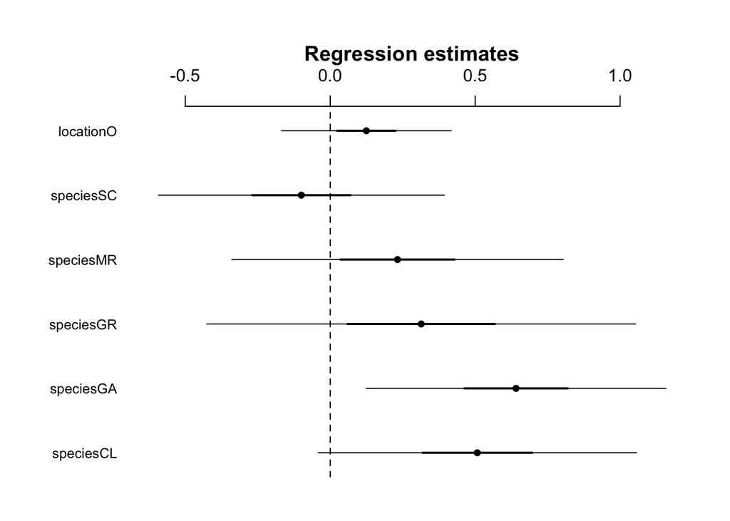

```r
coefplot2(mod2.1)
```

# Myc and lesion Correlation Model

*NOTE: Yprime = corr coefficient of Myc and Lesion at every cross per indiv*

### Model selection

```r
# calculating the r
Root_size$mean_rootsize <- rowSums(Root_size[,2:11])/length(Root_size[,2:11])
names(Root_size)[1]<-"indiv2"

fdata_rs <- merge(fdata, Root_size, by=c("indiv2","location","pop","species"))
indivCODE <- as.character(unique(fdata_rs$indiv2))
dfcorr <-data.frame(indiv2=c(0),r=c(0))
for (i in 1:length(indivCODE)){
  dat1<-NULL
  dat1<-fdata_rs[fdata_rs$indiv2==indivCODE[i],]
  dfcorr[i,1] <- indivCODE[i]
  dfcorr[i,2] <- cor(as.numeric(dat1$Mycorrhiza),as.numeric(dat1$Lesion))
}
dfcorr %>% drop_na()->dfcorr

fdata_rs.corr <- merge(dfcorr, Root_size, by="indiv2")
shapiro.test(fdata_rs.corr$r)
```

```
##
##  Shapiro-Wilk normality test
##
## data:  fdata_rs.corr$r
## W = 0.98168, p-value = 0.008497
```

```r
fdata_rs.corr$r.t<-fdata_rs.corr$r+1
CorrLM<-lm(r.t~ species * location * mean_rootsize,data=fdata_rs.corr)

bc<-boxcox(CorrLM, lambda = seq(-2, 2, 0.1))
```

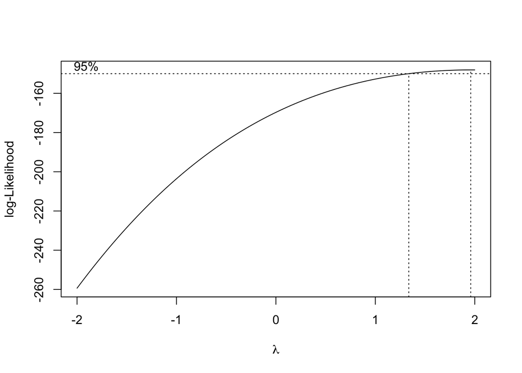

```r
lambda <- bc$x[which.max(bc$y)]
fdata_rs.corr <- cbind(fdata_rs.corr, ((fdata_rs.corr$r.t^lambda)-1)/lambda)
names(fdata_rs.corr)[length(fdata_rs.corr)] <- "Yprime"
shapiro.test(fdata_rs.corr$Yprime)
```

```
##
##  Shapiro-Wilk normality test
##
## data:  fdata_rs.corr$Yprime
## W = 0.9952, p-value = 0.7581
```

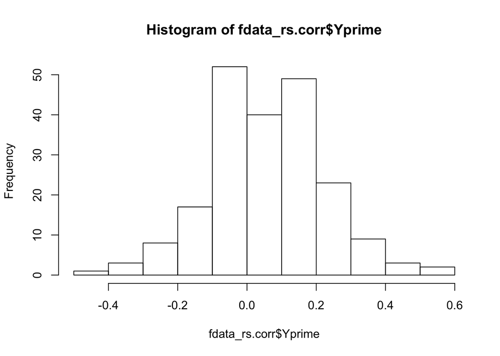

```r
hist(fdata_rs.corr$Yprime)
```

```r
CorrLMERBC<-lmer(Yprime~ species + location + mean_rootsize +
                   location:species +
                   (1|pop),
                 data=fdata_rs.corr)
pr<-resid(CorrLMERBC, type='pearson')
n<-nrow(fdata_rs.corr)
c<-length(coef(CorrLMERBC))
(Disp<-sum(pr^2)/(n-c))
```

```
## [1] 0.02396926
```

```
## NOTE: location:mean_rootsize does not appear in the model
```

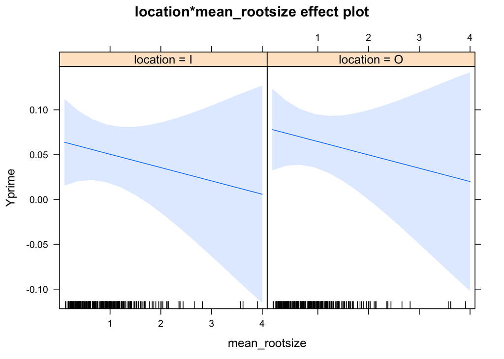

```r
plot(effect("location:mean_rootsize", CorrLMERBC))
```

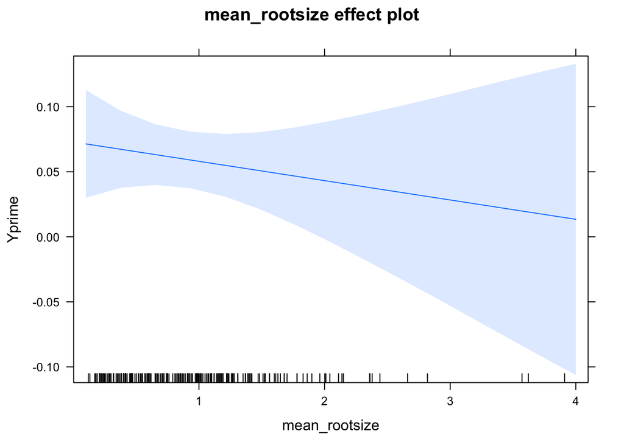

```r
plot(effect("mean_rootsize", CorrLMERBC))
```

#### LRT

```r
CorrLMERBC<-lmer(Yprime~ species + location + mean_rootsize +
                   location:species +
                   (1|pop),
                 data=fdata_rs.corr)

CorrLMERBC1<-lmer(Yprime~ species + location + mean_rootsize+
                   (1|pop),
                 data=fdata_rs.corr)
anova(CorrLMERBC1, CorrLMERBC)
```

```
## refitting model(s) with ML (instead of REML)
```

|  | Df | AIC | BIC | logLik | deviance | Chisq | Chi Df | Pr(>Chisq) |
| --- | --- | --- | --- | --- | --- | --- | --- | --- |
| CorrLMERBC1 | 10 | -157.9307 | -124.6035 | 88.96533 | -177.9307 | NA | NA | NA |
| CorrLMERBC | 15 | -155.8754 | -105.8846 | 92.93768 | -185.8754 | 7.944691 | 5 | 0.1593103 |

```r
CorrLMERBC2<-lmer(Yprime~ species + location +
                   (1|pop),
                 data=fdata_rs.corr)
anova(CorrLMERBC2, CorrLMERBC1)
```

```
## refitting model(s) with ML (instead of REML)
```

|  | Df | AIC | BIC | logLik | deviance | Chisq | Chi Df | Pr(>Chisq) |
| --- | --- | --- | --- | --- | --- | --- | --- | --- |
| CorrLMERBC2 | 9 | -159.7342 | -129.7397 | 88.86708 | -177.7342 | NA | NA | NA |
| CorrLMERBC1 | 10 | -157.9307 | -124.6035 | 88.96533 | -177.9307 | 0.1965112 | 1 | 0.6575517 |

```r
CorrLMERBC3<-lmer(Yprime~ species +
                    (1|pop),
                  data=fdata_rs.corr)
anova(CorrLMERBC3, CorrLMERBC2)
```

```
## refitting model(s) with ML (instead of REML)
```

|  | Df | AIC | BIC | logLik | deviance | Chisq | Chi Df | Pr(>Chisq) |
| --- | --- | --- | --- | --- | --- | --- | --- | --- |
| CorrLMERBC3 | 8 | -161.3255 | -134.6637 | 88.66275 | -177.3255 | NA | NA | NA |
| CorrLMERBC2 | 9 | -159.7342 | -129.7397 | 88.86708 | -177.7342 | 0.4086605 | 1 | 0.5226502 |

```r
CorrLMERBC4<-lmer(Yprime~ 1+
                    (1|pop),
                  data=fdata_rs.corr)
anova(CorrLMERBC3, CorrLMERBC4)
```

```
## refitting model(s) with ML (instead of REML)
```

|  | Df | AIC | BIC | logLik | deviance | Chisq | Chi Df | Pr(>Chisq) |
| --- | --- | --- | --- | --- | --- | --- | --- | --- |
| CorrLMERBC4 | 3 | -159.8446 | -149.8465 | 82.92232 | -165.8446 | NA | NA | NA |
| CorrLMERBC3 | 8 | -161.3255 | -134.6637 | 88.66275 | -177.3255 | 11.48085 | 5 | 0.04263696 |

### Descriptive stats

```r
pr<-resid(CorrLMERBC3, type='pearson')
n<-nrow(fdata_rs.corr)
c<-length(coef(CorrLMERBC3))
(Disp<-sum(pr^2)/(n-c))
```

```
## [1] 0.02498001
```

```r
summary(CorrLMERBC)
```

```
## Linear mixed model fit by REML ['lmerMod']
## Formula: Yprime ~ species + location + mean_rootsize + location:species +
##     (1 | pop)
##    Data: fdata_rs.corr
##
## REML criterion at convergence: -124.5
##
## Scaled residuals:
##      Min       1Q   Median       3Q      Max
## -2.62209 -0.67060 -0.01734  0.64036  2.75478
##
## Random effects:
##  Groups   Name        Variance Std.Dev.
##  pop      (Intercept) 0.00000  0.0000
##  Residual             0.02545  0.1595
## Number of obs: 207, groups:  pop, 11
##
## Fixed effects:
##                      Estimate Std. Error t value
## (Intercept)          0.086625   0.052372   1.654
## speciesCL            0.015220   0.057897   0.263
## speciesGA           -0.082432   0.060792  -1.356
## speciesGR           -0.048992   0.091350  -0.536
## speciesMR            0.071024   0.061448   1.156
## speciesSC           -0.054922   0.053745  -1.022
## locationO           -0.004178   0.058509  -0.071
## mean_rootsize       -0.014865   0.019840  -0.749
## speciesCL:locationO  0.066067   0.079644   0.830
## speciesGA:locationO  0.020744   0.076970   0.270
## speciesGR:locationO  0.136416   0.112319   1.214
## speciesMR:locationO -0.111666   0.082404  -1.355
## speciesSC:locationO  0.040709   0.072250   0.563
```

```
##
## Correlation matrix not shown by default, as p = 13 > 12.
## Use print(x, correlation=TRUE)  or
##   vcov(x)     if you need it
```

```r
confint(CorrLMERBC)
```

```
## Computing profile confidence intervals ...
```

[output not shown]

```
##                           2.5 %     97.5 %
## .sig01               0.00000000 0.04149701
## .sigma               0.14068333 0.17060727
## (Intercept)         -0.01320996 0.18645958
## speciesCL           -0.09514713 0.12558781
## speciesGA           -0.19831677 0.03345361
## speciesGR           -0.22312928 0.12514578
## speciesMR           -0.04611215 0.18816087
## speciesSC           -0.15737471 0.04753068
## locationO           -0.11571115 0.10735471
## mean_rootsize       -0.05268396 0.02295482
## speciesCL:locationO -0.08575510 0.21788838
## speciesGA:locationO -0.12597969 0.16746852
## speciesGR:locationO -0.07769408 0.35052585
## speciesMR:locationO -0.26874864 0.04541618
## speciesSC:locationO -0.09701878 0.17843579
```

# Everything on lesion

### Model selection

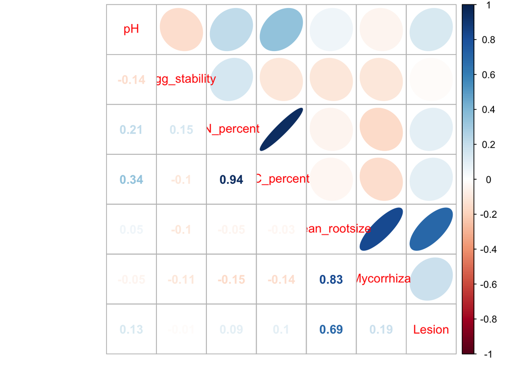

```r
var<-fulldata[,c(5,6,8,9,22,23,24)]
covar_cor = cor(var)
corrplot.mixed(covar_cor, upper = "ellipse", lower = "number")
```

```r
Nutrient_PCA = dudi.pca(df = var[, c(3, 4)], scannf = FALSE, nf = 1)
Nutrient_PCA$co
```

|  | Comp1 |
| --- | --- |
| N_percent | 0.9855557 |
| C_percent | 0.9855557 |

```r
Nutrient_PCA$eig/sum(Nutrient_PCA$eig)
```

```
## [1] 0.97132001 0.02867999
```

```r
fulldata$Nutrient_PC1 = Nutrient_PCA$li[,1]

mod10.nbinom <- glmmadmb(Lesion ~ Mycorrhiza + scale(mean_rootsize) + species +
                      scale(pH)+ scale(Agg_stability) + Nutrient_PC1 +
                      (1 | pop)+
                      Mycorrhiza:Nutrient_PC1 + Mycorrhiza:scale(mean_rootsize) +
                      Mycorrhiza:species + Mycorrhiza:scale(pH) +
                      Mycorrhiza:scale(Agg_stability),
                    data = fulldata,family = "nbinom1")
mod10.nbinom.ind <- glmmadmb(Lesion ~ Mycorrhiza + scale(mean_rootsize) + species +
                      scale(pH)+ scale(Agg_stability) + Nutrient_PC1 +
                      (1 | pop)+(1 | indiv)+
                      Mycorrhiza:Nutrient_PC1 + Mycorrhiza:scale(mean_rootsize) +
                      Mycorrhiza:species + Mycorrhiza:scale(pH) +
                      Mycorrhiza:scale(Agg_stability),
                    data = fulldata,family = "nbinom1")

# mod10.poisson <- glmmadmb(Lesion ~ Mycorrhiza + scale(mean_rootsize) + species +
                      # scale(pH)+ scale(Agg_stability) + Nutrient_PC1 +
                      # (1 | pop)+
                      # Mycorrhiza:Nutrient_PC1 + Mycorrhiza:scale(mean_rootsize) +
                      # Mycorrhiza:species + Mycorrhiza:scale(pH) +
                      # Mycorrhiza:scale(Agg_stability),
                    # data = fulldata,family = "poisson")
#fails
mod10.poisson.ind <- glmmadmb(Lesion ~ Mycorrhiza + scale(mean_rootsize) + species +
                      scale(pH)+ scale(Agg_stability) + Nutrient_PC1 +
                      (1 | pop)+(1 | indiv)+
                      Mycorrhiza:Nutrient_PC1 + Mycorrhiza:scale(mean_rootsize) +
                      Mycorrhiza:species + Mycorrhiza:scale(pH) +
                      Mycorrhiza:scale(Agg_stability),
                    data = fulldata,family = "poisson")

mod10.binom <- glmmadmb(binlesionF ~ Mycorrhiza + scale(mean_rootsize) + species +
                      scale(pH)+ scale(Agg_stability) + Nutrient_PC1 +
                      (1 | pop)+
                      Mycorrhiza:Nutrient_PC1 + Mycorrhiza:scale(mean_rootsize) +
                      Mycorrhiza:species + Mycorrhiza:scale(pH) +
                      Mycorrhiza:scale(Agg_stability),
                    data = fulldata,family = "binomial")
# mod10.binom.ind <- glmmadmb(binlesionF ~ Mycorrhiza + scale(mean_rootsize) + species +
                      # scale(pH)+ scale(Agg_stability) + Nutrient_PC1 +
                      # (1 | pop) + (1 | indiv)+
                      # Mycorrhiza:Nutrient_PC1 + Mycorrhiza:scale(mean_rootsize) +
                      # Mycorrhiza:species + Mycorrhiza:scale(pH) +
                      # Mycorrhiza:scale(Agg_stability),
                    # data = fulldata,family = "binomial")
#fail

ICtab(mod10.binom, mod10.poisson.ind, mod10.nbinom, mod10.nbinom.ind)
```

```
##                   dAIC  df
## mod10.binom         0.0 21
## mod10.poisson.ind 147.9 22
## mod10.nbinom      147.9 22
## mod10.nbinom.ind  149.9 23
```